# Generalized Linear Models

Chun-Hao Yang

## Outline

- Classical Linear Model
  - Ordinary Least Squares (OLS) Estimation
  - Maximum Likelihood (ML) Estimation
  - Penalty and Regularization
- Generalized Linear Models
  - Logistic Regression
  - Multinomial Regression
- Non-linear Models
  - Generalized Additive Models (GAM)
  - Projection Pursuit Regression (PPR)

## Classical Linear Model

- Given $p$ covariates $x_1, \ldots, x_p$ and a response variable $y$, the classical linear model assumes that the relationship between the $x_i$’s and $y$ is linear:
  $$y = \beta_0 + \beta_1 x_1 + \cdots + \beta_p x_p.$$
- Denote $\boldsymbol{x} = (1, x_{1}, \ldots, x_{p})^T$ and $\boldsymbol{\beta} = (\beta_0, \beta_1, \ldots, \beta_p)^T$, the model can be written as
  $$y = \boldsymbol{x}^T\boldsymbol{\beta}.$$
- Suppose now we have $n$ samples $(\boldsymbol{x}_1, y_1), \ldots (\boldsymbol{x}_n, y_n)$ and we believe that the linear model above is a reasonable approximation of the relationship between the $\boldsymbol{x}_i$’s and $y_i$.
- The goal is to estimate the **model parameter** $\boldsymbol{\beta}$.

## Ordinary Least Squares (OLS) Estimation

- The most common method to estimate $\boldsymbol{\beta}$ is the **ordinary least squares (OLS)** estimation, that is, we find $\boldsymbol{\beta}$ that minimizes the sum of squared residuals:
  $$\hat{\boldsymbol{\beta}} = \argmin_{\boldsymbol{\beta}} \sum_{i=1}^n (y_i - \boldsymbol{x}_i^T\boldsymbol{\beta})^2.$$
- Denoting
  $$\boldsymbol{y} = \begin{bmatrix} y_1 \\ \vdots \\ y_n \end{bmatrix}, \quad
  \boldsymbol{X} = \begin{bmatrix} \boldsymbol{x}_1^T \\ \vdots \\ \boldsymbol{x}_n^T \end{bmatrix},$$
  the minimization problem can be written as
  $$\hat{\boldsymbol{\beta}} = \argmin_{\boldsymbol{\beta}} \|\boldsymbol{y} - \boldsymbol{X}\boldsymbol{\beta}\|_2^2.$$

## Ordinary Least Squares (OLS) Estimation

- Let $L(\boldsymbol{\beta}) = \|\boldsymbol{y} - \boldsymbol{X}\boldsymbol{\beta}\|_2^2$. This is often called the **loss function**.
- Taking the gradient of $L(\boldsymbol{\beta})$ with respect to $\boldsymbol{\beta}$ and setting it to zero, we have
  $$\nabla_{\boldsymbol{\beta}} L(\boldsymbol{\beta}) = -2\boldsymbol{X}^T(\boldsymbol{y} - \boldsymbol{X}\boldsymbol{\beta}) = 0.$$
- The OLS estimation has a closed-form solution:
  $$\hat{\boldsymbol{\beta}}^{\text{OLS}} = (\boldsymbol{X}^T\boldsymbol{X})^{-1}\boldsymbol{X}^T\boldsymbol{y}.$$
- To ensure the existence of the inverse, we need to assume that $\boldsymbol{X}^T\boldsymbol{X}$ is invertible, that is, the columns of $\boldsymbol{X}$ are linearly independent.
- To verify that $\hat{\boldsymbol{\beta}}^{\text{OLS}}$ is indeed the minimizer, we need to show that the Hessian of $L(\boldsymbol{\beta})$ is positive definite:
  $$\nabla^2_{\boldsymbol{\beta}} L(\boldsymbol{\beta}) = 2\boldsymbol{X}^T\boldsymbol{X} \succ 0.$$

## Maximum Likelihood (ML) Estimation

- Another way to estimate $\boldsymbol{\beta}$ is the **maximum likelihood (ML)** estimation.
- Suppose that the response variable $y$ is normally distributed with mean $\mu(\boldsymbol{x}) = \boldsymbol{x}^T\boldsymbol{\beta}$ and variance $\sigma^2$:
  $$y \mid \boldsymbol{x} \sim \mathcal{N}(\boldsymbol{x}^T\boldsymbol{\beta}, \sigma^2).$$
- Assuming the samples are i.i.d, the likelihood function is
  $$L(\boldsymbol{\beta}, \sigma^2) = \prod_{i=1}^n \frac{1}{\sqrt{2\pi\sigma^2}}\exp\left(-\frac{(y_i - \boldsymbol{x}_i^T\boldsymbol{\beta})^2}{2\sigma^2}\right).$$
- The log-likelihood function is
  $$\ell(\boldsymbol{\beta}, \sigma^2) = -\frac{n}{2}\log(2\pi\sigma^2) - \frac{1}{2\sigma^2}\sum_{i=1}^n (y_i - \boldsymbol{x}_i^T\boldsymbol{\beta})^2 = -\frac{n}{2}\log(2\pi\sigma^2) - \frac{1}{2\sigma^2}\|\boldsymbol{y} - \boldsymbol{X}\boldsymbol{\beta}\|_2^2.$$
- The ML estimation is $\hat{\boldsymbol{\beta}}, \hat{\sigma}^2 = \argmax_{\boldsymbol{\beta}, \sigma^2} \ell(\boldsymbol{\beta}, \sigma^2)$.

## Maximum Likelihood (ML) Estimation

- Taking the gradient of $\ell(\boldsymbol{\beta}, \sigma^2)$ with respect to $\boldsymbol{\beta}$ and $\sigma^2$ and setting them to zero, we have
  $$\nabla_{\boldsymbol{\beta}} \ell(\boldsymbol{\beta}, \sigma^2) = \frac{1}{\sigma^2} \boldsymbol{X}^T(\boldsymbol{y} - \boldsymbol{X}\boldsymbol{\beta}) = 0,$$
  and
  $$\frac{\partial}{\partial \sigma^2} \ell(\boldsymbol{\beta}, \sigma^2) = -\frac{n}{2\sigma^2} + \frac{1}{2\sigma^4} \|\boldsymbol{y} - \boldsymbol{X}\boldsymbol{\beta}\|_2^2 = 0.$$
- The ML estimation has a closed-form solution:
  $$\hat{\boldsymbol{\beta}}^{\text{MLE}} = (\boldsymbol{X}^T\boldsymbol{X})^{-1}\boldsymbol{X}^T\boldsymbol{y}, \quad
  \hat{\sigma}^2 = \frac{1}{n}\|\boldsymbol{y} - \boldsymbol{X}\hat{\boldsymbol{\beta}}^{\text{MLE}}\|_2^2.$$
- The MLE of $\boldsymbol{\beta}$ is the same as the OLS estimation.

## OLS v.s. ML Estimation

- Compared to the OLS estimation, the ML estimation requires an additional assumption on the distribution of $y$.
- In ths case of linear regression, the normality assumption is the most common one.
- An equivalent way to express the linear regression under the normality assumption is
  $$y = \boldsymbol{x}^T\boldsymbol{\beta} + \varepsilon, \quad \varepsilon \sim \mathcal{N}(0, \sigma^2).$$
- One of the advantages of the ML estimation is that it provides a way to estimate the variance of the estimated parameter $\hat{\boldsymbol{\beta}}$:
  $$\begin{align*}
  \var(\hat{\boldsymbol{\beta}}^{\text{MLE}}) & = \var((\boldsymbol{X}^T\boldsymbol{X})^{-1}\boldsymbol{X}^T\boldsymbol{y}) \\
  & = (\boldsymbol{X}^T\boldsymbol{X})^{-1}\boldsymbol{X}^T\var(\boldsymbol{y})\boldsymbol{X}(\boldsymbol{X}^T\boldsymbol{X})^{-1} \\
  & = (\boldsymbol{X}^T\boldsymbol{X})^{-1}\boldsymbol{X}^T(\sigma^2 I)\boldsymbol{X}(\boldsymbol{X}^T\boldsymbol{X})^{-1} \\
  & = \sigma^2 (\boldsymbol{X}^T\boldsymbol{X})^{-1}.
  \end{align*}$$

## Useful Properties of MLE

- Under the normality assumption, the MLE has the following properties:
  - **Unbiasedness**: $\E(\hat{\boldsymbol{\beta}}^{\text{MLE}}) = \boldsymbol{\beta}$.
  - **Normality**: $\hat{\boldsymbol{\beta}}^{\text{MLE}} \sim \mathcal{N}(\boldsymbol{\beta}, \sigma^2 (\boldsymbol{X}^T\boldsymbol{X})^{-1})$.
  - **Prediction Intervals**: for a given $\boldsymbol{x}^{\star}$, the predicted value is $y^{\star} = \boldsymbol{x}^{\star T}\hat{\boldsymbol{\beta}}^{\text{MLE}}$ and the prediction interval is
    $$y^{\star} \pm t_{n-p-1, 1-\alpha/2} \hat{\sigma} \sqrt{1 + \boldsymbol{x}^{\star T}(\boldsymbol{X}^T\boldsymbol{X})^{-1}\boldsymbol{x}^{\star}}.$$
  - We can also derive the confidence intervals and hypothesis tests for $c^T\boldsymbol{\beta}$ for any $c$.

## What if the samples are not i.i.d?

- If the samples are not i.i.d, we can model the joint distribution of the samples:
  $$\boldsymbol{y} \mid \boldsymbol{X} \sim \mathcal{N}(\boldsymbol{X}\boldsymbol{\beta}, \sigma^2 W^{-1})$$
  where $W$ is an $n\times n$ covariance matrix describing the dependence between the samples.
- Consider the transformation $\widetilde{\boldsymbol{y}} = W^{1/2}\boldsymbol{y}$ and $\widetilde{\boldsymbol{X}} = W^{1/2}\boldsymbol{X}$. The model becomes
  $$\widetilde{\boldsymbol{y}} \mid \widetilde{\boldsymbol{X}} \sim \mathcal{N}(\widetilde{\boldsymbol{X}}\boldsymbol{\beta}, \sigma^2 I).$$
- Therefore the MLE for $\boldsymbol{\beta}$ is
  $$\hat{\boldsymbol{\beta}}^{\text{MLE}} = (\widetilde{\boldsymbol{X}}^T\widetilde{\boldsymbol{X}})^{-1}\widetilde{\boldsymbol{X}}^T\widetilde{\boldsymbol{y}} = (\boldsymbol{X}^TW\boldsymbol{X})^{-1}\boldsymbol{X}^TW\boldsymbol{y},$$
  which is called the **weighted least squares** estimation.

## Penalized Likelihood Estimation

- However, in practice, the MLE might not be the best choice.
- For example, when $X$ contains columns that are close to **collinear** or if the number of covariates $p$ is large, computing $(X^TX)^{-1}$ will become numerically unstable.
- One of the most common ways to address this issue is to add **penalization** or **regularization**.
- The idea is to add a penalty term to the negative log-likelihood function, i.e.,
  $$-\ell(\boldsymbol{\beta}, \sigma^2) + \lambda \cdot \text{pen}(\boldsymbol{\beta}).$$
- That is, we are looking for the $\boldsymbol{\beta}$ that minimizes the negaive log-likelihood and the penalty.
- The extra term $\lambda$ is a **hyperparameter** that controls the trade-off between the likelihood and the penalty.

## Ridge Regression

- One of the most common penalization methods is the **Ridge regression**.
- The penalty term is the $L_2$ norm of $\boldsymbol{\beta}$:
  $$\text{pen}(\boldsymbol{\beta}) = \|\boldsymbol{\beta}\|_2^2 = \sum_{j=0}^p \beta_j^2.$$
- The Ridge estimator is
  $$\hat{\boldsymbol{\beta}}^{\text{ridge}} = \argmin_{\boldsymbol{\beta}} \|\boldsymbol{y} - \boldsymbol{X}\boldsymbol{\beta}\|_2^2 + \lambda \|\boldsymbol{\beta}\|_2^2.$$
- Let $L_{\lambda}(\boldsymbol{\beta}) = \|\boldsymbol{y} - \boldsymbol{X}\boldsymbol{\beta}\|_2^2 + \lambda \|\boldsymbol{\beta}\|_2^2$ and set the gradient to zero
  $$\nabla_{\boldsymbol{\beta}} L_{\lambda}(\boldsymbol{\beta}) = -2\boldsymbol{X}^T(\boldsymbol{y} - \boldsymbol{X}\boldsymbol{\beta}) + 2\lambda \boldsymbol{\beta} = 0.$$
- Hence the Ridge estimator is
  $$\hat{\boldsymbol{\beta}}^{\text{ridge}} = (\boldsymbol{X}^T\boldsymbol{X} + \lambda I)^{-1}\boldsymbol{X}^T\boldsymbol{y}.$$

## Ridge Regression

- Typically, penalization of the intercept is not desired in Ridge regression so that $\beta_0$ should be excluded from the penalty term.
- A simple way to achieve this is to center all covariates and the responses so that $\bar{y} = 0$ and $\bar{\boldsymbol{x}} = 0$ which automatically results in $\hat{\beta}_0 = 0$.
- A second approach is to use the following penalty term:
  $$\text{pen}(\boldsymbol{\beta}) = \sum_{j=1}^p \beta_j^2 = \boldsymbol{\beta}^TK\boldsymbol{\beta},$$
  where $K = \text{diag}(0, 1, \ldots, 1)$.
- The Ridge estimator is
  $$\hat{\boldsymbol{\beta}}^{\text{ridge}} = (\boldsymbol{X}^T\boldsymbol{X} + \lambda K)^{-1}\boldsymbol{X}^T\boldsymbol{y}.$$

## Ridge v.s. OLS

- The Ridge estimator is **biased** and the OLS is **unbiased**.
- However, one can show that the Ridge estimator has a smaller variance than the OLS estimator.
- When choosing an appropriate hyperparameter $\lambda$, the Ridge estimator can have a smaller **mean squared error (MSE)** than the OLS estimator.
- The Ridge estimator is **shrinkage** estimator that shrinks the coefficients towards zero (large value of $\lambda$ yields a stronger shrinkage).
- The Ridge estimator is particularly useful when the covariates are collinear or when the number of covariates is large.
- The choice of $\lambda$ is often done using cross-validation.

## Least Absolute Shrinkage and Selection Operator (LASSO)

- Another common penalization method is the **least absolute shrinkage and selection operator (LASSO)**.
- The penalty term is the $L_1$ norm of $\boldsymbol{\beta}$:
  $$\text{pen}(\boldsymbol{\beta}) = \sum_{j=1}^p |\beta_j|.$$
- The LASSO estimator is
  $$\hat{\boldsymbol{\beta}}^{\text{LASSO}} = \argmin_{\boldsymbol{\beta}} \|\boldsymbol{y} - \boldsymbol{X}\boldsymbol{\beta}\|_2^2 + \lambda \sum_{j=1}^p |\beta_j|.$$

## LASSO Estimation

- Note that the objective function of the LASSO estimator is not differentiable, due to the absolute value term.
- No closed-form solution for the LASSO estimator is available. However, it can be solved using the **Least Angle Regression**<sup>1</sup> or the **coordinate descent**<sup>2</sup> algorithm.
- One of the key properties of the LASSO estimator is that it produces **sparse** solutions, i.e., some of the estimated coefficients are exactly zero.
- This is particularly useful for **variable selection**, i.e., to identify the important covariates.
[^1]: Efron, B., Hastie, T., Johnstone, I., & Tibshirani, R. (2004). Least angle regression. *The Annals of Statistics*, 32(2), pages 407–499.
[^2]: Friedman, J. H., Hastie, T., & Tibshirani, R. (2010). Regularization Paths for Generalized Linear Models via Coordinate Descent. *Journal of Statistical Software*, 33(1), pages 1–22.

## Ridge v.s. LASSO ($L_2$ penalty v.s. $L_1$ penalty)

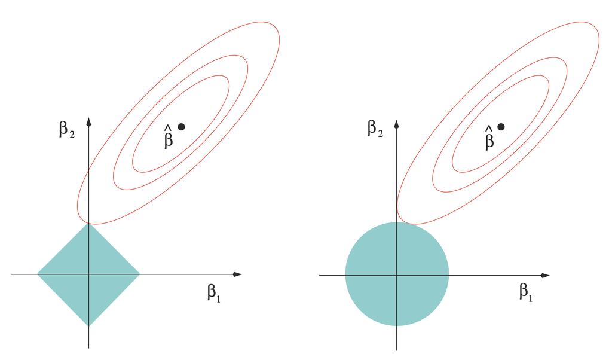

Figure 3.11 of ESL

## Elastic-Net

- The **Elastic-Net**<sup>1</sup> is a combination of the Ridge and the LASSO.
- The penalty term is a combination of the $L_1$ and $L_2$ norm of $\boldsymbol{\beta}$:
  $$\text{pen}(\boldsymbol{\beta}) = \lambda_1 \sum_{j=1}^p |\beta_j| + \lambda_2 \sum_{j=1}^p \beta_j^2.$$
- The Elastic-Net estimator is
  $$\hat{\boldsymbol{\beta}}^{\text{EN}} = \argmin_{\boldsymbol{\beta}} \|\boldsymbol{y} - \boldsymbol{X}\boldsymbol{\beta}\|_2^2 + \lambda_1 \sum_{j=1}^p |\beta_j| + \lambda_2 \sum_{j=1}^p \beta_j^2.$$
- Through the choice of $\lambda_1$ and $\lambda_2$, the Elastic-Net can be used to achieve the benefits of both the ridge and the LASSO.
[^3]: Zou, H., & Hastie, T. (2005). Regularization and variable selection via the elastic net. *Journal of the Royal Statistical Society Series B: Statistical Methodology*, 67(2), pages 301-320.

## Example - Sparse features

- We generate a synthetic dataset with 50 samples and 10 features.
- Only 5 out of the 10 features are informative.
- We fit the linear regression, Ridge, LASSO, and Elastic-Net models to the data.

```python
from sklearn.linear_model import LinearRegression, Ridge
from sklearn.linear_model import Lasso, ElasticNet
from sklearn.datasets import make_regression

X, y, true_coef = make_regression(n_samples = 50, n_features = 10,
                                  n_informative = 5, noise = 5,
                                  coef = True, random_state = 42)

lm = LinearRegression().fit(X, y)
ridge = Ridge(alpha=1.0).fit(X, y)
lasso = Lasso(alpha=1.0).fit(X, y)
enet = ElasticNet(alpha=1.0, l1_ratio=0.5).fit(X, y)
```

## Example - Sparse features

| True Coef | Linear | Ridge | LASSO | Elastic-Net |
| --- | --- | --- | --- | --- |
| 57.078 | 56.306 | 55.626 | 55.459 | 40.091 |
| 0.000 | 0.173 | 0.471 | 0.000 | 1.685 |
| 0.000 | -0.185 | 0.073 | -0.000 | 1.556 |
| 35.610 | 33.877 | 33.447 | 33.189 | 25.617 |
| 0.000 | 0.702 | 1.655 | 0.000 | 8.187 |
| 60.577 | 60.568 | 59.158 | 59.634 | 38.185 |
| 0.000 | 1.586 | 1.838 | 0.650 | 4.251 |
| 64.592 | 64.964 | 63.242 | 63.704 | 37.886 |
| 0.000 | -0.440 | -0.428 | -0.000 | -1.682 |
| 98.652 | 99.563 | 96.871 | 98.682 | 61.042 |

# Generalized Linear Models

## Beyond Normality

- When the response variable is not real-valued, the classical linear model is not appropriate.
- For example:
  - Binary responses: $y \in \{0, 1\}$.
  - Count data: $y \in \{0, 1, 2, \ldots\}$.
  - Multinomial responses: $y \in \{1, 2, \ldots, K\}$.
- In these cases, neither the OLS estimation nor the normality assumption is appropriate.
- Generalized Linear Model (GLM) is a generalization of the classical linear model that allows for non-normal responses.
- The key is to find a reasonable distribution to model $y$.

## Binary Responces: Logistic regression

- When $y$ is binary, we can use the Bernoulli distribution
  $$Y \mid \boldsymbol{x} \sim \text{Ber}(p(\boldsymbol{x})),$$
- That is, $\P(Y = 1 \mid \boldsymbol{x}) = p(\boldsymbol{x})$ and $\P(Y = 0 \mid \boldsymbol{x}) = 1 - p(\boldsymbol{x})$ and the expectation is $\E(Y \mid \boldsymbol{x}) = p(\boldsymbol{x})$.
- The logistic regression model assumes
  $$p(\boldsymbol{x}) = \frac{1}{1 + \exp(-\boldsymbol{x}^T\boldsymbol{\beta})}.$$
- Equivalently, we can write
  $$\log\left(\frac{p(\boldsymbol{x})}{1 - p(\boldsymbol{x})}\right) = \boldsymbol{x}^T\boldsymbol{\beta}.$$
- That is, the log-odds of the event $\{Y = 1\}$ is linear in $\boldsymbol{x}$.

## ML Estimation for Logistic Regression

- Given $n$ samples $(\boldsymbol{x}_1, y_1), \ldots (\boldsymbol{x}_n, y_n)$, the likelihood function is
  $$L(\boldsymbol{\beta}) = \prod_{i=1}^n p(\boldsymbol{x}_i)^{y_i} (1 - p(\boldsymbol{x}_i))^{1 - y_i}.$$
- The log-likelihood function is
  $$\ell(\boldsymbol{\beta}) = \sum_{i=1}^n y_i \log(p(\boldsymbol{x}_i)) + (1 - y_i)\log(1 - p(\boldsymbol{x}_i)).$$
- Hence the MLE of $\boldsymbol{\beta}$ is
  $$\hat{\boldsymbol{\beta}}^{\text{MLE}} = \argmax_{\boldsymbol{\beta}} \ell(\boldsymbol{\beta}).$$
- The negative log-likelihood is also called the **cross-entropy** loss, i.e., maximizing the likelihood is equivalent to minimizing the cross-entropy loss.

## Cross-Entropy Loss

- In Information Theory, the cross-entropy is defined as
  $$H(p, q) = -\sum_{x} p(x) \log(q(x)) = -\E_p[\log(q(X))],$$
  where $p(x)$ and $q(x)$ are two discrete probability distributions.
- Large value of cross-entropy indicates that the two distributions are different.
- In the case of logistic regression, we want to measure the discrepancy between the data $[y_i, 1-y_i]$ and the model $[p(\boldsymbol{x}_i), 1 - p(\boldsymbol{x}_i)]$.
- Hence the cross-entropy is
  $$-\sum_{i=1}^n y_i \log(p(\boldsymbol{x}_i)) + (1 - y_i)\log(1 - p(\boldsymbol{x}_i)).$$

## Exponential family

- Recall that an exponential family is a family of distributions
  $$f(x \mid \theta) = h(x)\exp(\theta^T T(x) - \psi(\theta))$$
  where $\theta \in \R^k$ and $T(x) = [T_1(x), \ldots, T_k(x)]^T$.
- The parameter $\theta$ is called the **natural parameter** or the **canonical parameter** and $T(x)$ is the **sufficient statistic**.
- Two useful properties (from Bartlett’s identities):
  - $\E(T(X)) = \nabla_{\theta}\psi(\theta)$
  - $\var(T(X)) = \text{Hess}(\psi(\theta)) = \nabla^2_{\theta} \psi(\theta)$.
- That is, the relationship between the parameter $\theta$ and the expectation $\E(T(X))$ determined by $\nabla \psi$.

## Examples

- Normal disribution:
  $$f(x \mid \mu, \sigma^2) = \exp\left(-\frac{1}{2\sigma^2} x^2 + \frac{\mu}{\sigma^2}x - \frac{\mu^2}{2\sigma^2} - \frac{1}{2}\log(2\pi\sigma^2)\right), \quad x \in \R$$
  - $\theta = \left(-\frac{1}{2\sigma^2}, \frac{\mu}{\sigma^2}\right)$, $T(x) = (-x^2, x)$, $\psi(\theta) = -\frac{\theta_2^2}{4\theta_1} - \frac{1}{2}\log\left(-\frac{\theta_1}{\pi}\right)= \frac{\mu^2}{2\sigma^2} + \frac{1}{2}\log(2\pi\sigma^2)$
- Bernoulli distribution:
  $$f(x \mid p) = p^x(1-p)^{1-x} = \exp\left(x\log\frac{p}{1-p} + \log(1-p)\right), \quad x \in \{0, 1\}$$
  - $\theta = \log\frac{p}{1-p}$, $T(x) = x$, $\psi(\theta) = -\log(1-p) = \log(1 + e^{\theta})$
- Poisson distribution:
  $$f(x \mid \lambda) = \frac{\lambda^x e^{\lambda}}{x!}= \frac{1}{x!}\exp(x\log\lambda - \lambda), \quad x = 0, 1, 2, \ldots$$
  - $\theta = \log\lambda$, $T(x) = x$, $\psi(\theta) = \exp(\theta) = \lambda$

## Generalized Linear Model (GLM)

- Let $Y$ be univariate, $\boldsymbol{x} \in \R^p$, and $\boldsymbol{\beta} \in \R^p$.
- A GLM is assuming $Y \mid \boldsymbol{x} \sim F_{\theta}$, where $\theta = \boldsymbol{x}^T\boldsymbol{\beta}$ and $F_\theta$ has the density function
  $$f(y \mid \theta) = h(y)\exp(\theta\cdot y - \psi(\theta)).$$
- Therefore
  $$\begin{align*}
  \E(Y \mid \boldsymbol{x}) & = \frac{d}{d\theta}\psi(\theta) = \psi^{\prime}(\boldsymbol{x}^T\boldsymbol{\beta}).
  \end{align*}$$
- Equivalently,
  $$g(\E(Y \mid \boldsymbol{x})) = \boldsymbol{x}^T\boldsymbol{\beta}$$
  where $g$ is the inverse of $\psi^{\prime}$.
- The function $g$ is called the **link function**.

## Logistic Regression

- For Bernoulli distributions, we have
  $$\theta = \log\frac{p}{1-p}, \quad \psi(\theta) = -\log(1-p) = \log(1 + e^{\theta}).$$
- Thus, $\psi^{\prime}(\theta) = \frac{e^{\theta}}{1 + e^{\theta}}$ and $g(p) = (\psi^{\prime})^{-1}(p) = \log\frac{p}{1-p}$. $\psi^{\prime}$ is called the **logistic function** and $g$ is called the **logit function**.
- Putting altogether, we have
  $$g(\E(Y \mid \boldsymbol{x})) = \log\left(\frac{p(\boldsymbol{x})}{1 - p(\boldsymbol{x})}\right) = \boldsymbol{x}^T\boldsymbol{\beta}$$
  or equivalently
  $$\P(Y = 1 \mid \boldsymbol{x}) = \psi^{\prime}(\boldsymbol{x}^T\boldsymbol{\beta}) = \frac{\exp(\boldsymbol{x}^T\boldsymbol{\beta})}{1 + \exp(\boldsymbol{x}^T\boldsymbol{\beta})}.$$

## Remarks

- The link function $g = (\psi^{\prime})^{-1}$ is sometimes called the **canonical link** function, since it is derived from the canonical representation of an exponential family.
- All we need for a link function is that it is invertible and matches the range of $\E(Y \mid \boldsymbol{x})$ and $\boldsymbol{x}^T\boldsymbol{\beta}$.
- For example, in the Bernoulli linear model, we could have used the **probit link** function
  $$g(u) = \Phi^{-1}(u): [0, 1] \to \R$$
  where $\Phi$ is the CDF of the standard normal distribution.
- This is called the **probit regression**.

## Multinomial Regression

- Multinomial regression is a generalization of Logistic regression to categorical variables with more than two categories.
- Suppose $Y$ is a categorical variable with $K$ categories, $Y \in \{1, 2, \ldots, K\}$.
- A more useful representation is to use the **one-hot encoding**:
  $$Y = [0, 0, \ldots, 1, \ldots, 0]^T$$
  where the $k$-th element is 1 and the rest are 0.
- The multinomial regression model assumes
  $$Y \mid \boldsymbol{x} \sim \text{Multi}(1, [p_1(\boldsymbol{x}), p_2(\boldsymbol{x}), \ldots, p_K(\boldsymbol{x})]^T)$$
  where $p_k(\boldsymbol{x}) = \P(Y = 1_k \mid \boldsymbol{x})$ and $1_k$ is the one-hot encoding of the $k$-th category.

## Multinomial Distribution

- The probability mass function of the $\text{Multi}(m,p)$ is
  $$f(x \mid p) = \frac{m!}{x_1!\cdots x_K!}\prod_{k=1}^K p_k^{x_k} = \frac{m!}{x_1!\cdots x_K!}\exp\left(\sum_{k=1}^K x_k\log p_k\right)$$
  where $x = [x_1, x_2, \ldots, x_K]^T$, $\sum_{k=1}^K x_k = m$, and $\sum_{k=1}^K p_k = 1$.
- Note that $p_K = 1 - p_1 - \ldots - p_{K-1}$ and therefore
  $$\begin{align*}
  f(x \mid p) & = \frac{m!}{x_1!\cdots x_K!}\exp\left(\sum_{k=1}^{K-1} x_k\log p_k + \left(m - \sum_{k=1}^{K-1} x_k\right)\log(1 - p_1 - \ldots - p_{K-1})\right)\\
  & = \frac{m!}{x_1!\cdots x_K!}\exp\left(\sum_{k=1}^{K-1} x_k\log\frac{p_k}{p_K} + m\log(1 - p_1 - \ldots - p_{K-1})\right).
  \end{align*}$$

## Softmax Function

- The canonical parameter is $\theta = [\log\frac{p_1}{p_K}, \ldots, \log\frac{p_{K-1}}{p_K}]^T$ and therefore $p_i = p_K\exp(\theta_i)$.
- Using the relationship $p_K = 1 - \sum_{k=1}^{K-1} p_k$, we have
  $$p_K = 1 - p_K\sum_{k=1}^{K-1} \exp(\theta_k) \quad \Rightarrow \quad p_K = \frac{1}{1 + \sum_{k=1}^{K-1} \exp(\theta_k)}.$$
- Hence (assume $m = 1$ for simplicity)
  $$\begin{align*}
  \psi(\theta) & = - \log(1 - p_1 - \ldots - p_{K-1})
  = - \log(1 - p_Ke^{\theta_1} - \ldots - p_Ke^{\theta_{K-1}})\\
  & = - \log\left(1 - \frac{\sum_{k=1}^{K-1} \exp(\theta_k)}{1 + \sum_{k=1}^{K-1} \exp(\theta_k)}\right)
  = \log\left(1 + \sum_{k=1}^{K-1} \exp(\theta_k)\right).
  \end{align*}$$
- Taking the derivative, we have the **softmax function**:
  $$\nabla_{\theta}\psi(\theta) = \left[\frac{\exp(\theta_1)}{1 + \sum_{k=1}^{K-1} \exp(\theta_k)}, \ldots, \frac{\exp(\theta_{K-1})}{1 + \sum_{k=1}^{K-1} \exp(\theta_k)}\right].$$

## Multinomial Regression

- The multinomial regression model is given by
  $$\begin{align*}
  \theta_i & = \boldsymbol{x}^T\boldsymbol{\beta}_i, \\
  p_i(\boldsymbol{x}) & = \frac{\exp(\theta_i)}{1 + \sum_{k=1}^{K-1} \exp(\theta_i)}, \quad i = 1, 2, \ldots, K-1,
  \end{align*}$$
  where $\boldsymbol{\beta}_i \in \R^p$.
- In fact, a more common representation is
  $$\begin{align*}
  \tilde{\theta}_i & = \boldsymbol{x}^T\tilde{\boldsymbol{\beta}}_i, \\
  p_i(\boldsymbol{x}) & = \frac{\exp(\tilde{\theta}_i)}{\sum_{k=1}^{K} \exp(\tilde{\theta}_i)}, \quad i = 1, 2, \ldots, K.
  \end{align*}$$
- The equivalence is due to the transformation $\theta_i = \tilde{\theta}_i - \tilde{\theta}_K$ and $\boldsymbol{\beta}_i = \tilde{\boldsymbol{\beta}}_i - \tilde{\boldsymbol{\beta}}_K$. We can also write
  $$[p_1(\boldsymbol{x}), \ldots, p_K(\boldsymbol{x})] = \texttt{softmax}(\boldsymbol{x}^T\boldsymbol{\beta}_1, \ldots, \boldsymbol{x}^T\boldsymbol{\beta}_K).$$

## Quick Summary

- A GLM is
  $$g(\E(Y \mid X = x)) = x^T\beta \Leftrightarrow \E(Y \mid X = x) = g^{-1}(x^T\beta).$$
- The link function $g$ connects the conditional expectation and the linear predictor and is chosen based on the distribution of $Y$.
- Examples:
  - Logistic regression: $g(p) = \log\left(\frac{p}{1-p}\right)$, $g^{-1}(x) = \frac{1}{1+e^{-x}}$.
  - Linear regression: $g(\mu) = \mu$.
  - Multinomial regression: softmax function.
  - There are other choices and the above are called the **canonical link functions**.

## Beyond Linearity

- Up to now, we have assumed that a linear relationship between the features and the (transformed) conditional expectation:
  $$g(\E(Y \mid \boldsymbol{x})) = \boldsymbol{x}^T\boldsymbol{\beta}$$
- However, this is a strong assumption and may not be appropriate in many cases.
- To remove this assumption, we can consider
  $$g(\E(Y \mid \boldsymbol{x})) = f(\boldsymbol{x})$$
  where $f: \R^p \to \R$ is an unknown function.
- The problem is now to estimate the function $f$.
- Depending on the restrictions on $f$, we can use different methods to estimate $f$.

## Generalized Additive Models (GAM)

- An additive model assumes that the unknown function $f$ is a sum of univariate functions:
  $$f(\boldsymbol{x}) = \beta_0 + f_1(x_1) + f_2(x_2) + \cdots + f_p(x_p).$$
- Therefore, the model is
  $$g(\E(Y \mid \boldsymbol{x})) = \beta_0 + f_1(x_1) + f_2(x_2) + \cdots + f_p(x_p).$$
- The functions $f_j: \R \to \R$ are unknown and need to be estimated.
- Nonparametric methods can be used to estimate the functions $f_j$, for example, kernel smoothing, splines, etc.
- The GAM is a generalization of the linear model that allows for non-linear relationships between the features and the conditional expectation.

## Projection Pursuit Regression (PPR)

- The **projection pursuit regression (PPR)**<sup>1</sup> model assumes:
  $$f(\boldsymbol{x}) = \sum_{m=1}^M f_m(\boldsymbol{x}^T\boldsymbol{\omega}_m),$$
  where $\boldsymbol{\omega}_m \in \R^p$ are unknown unit vectors and $f_m: \R \to \R$ are unknown functions.
- The scalar variable $V_m = \boldsymbol{x}^T\boldsymbol{\omega}_m$ is the projection of $\boldsymbol{x}$ onto the unit vector $\boldsymbol{\omega}_m$, and we seek $\boldsymbol{\omega}_m$ so that the model fits well, hence the name “projection pursuit.”
- If $M$ is taken arbitrarily large, for appropriate choice of $f_m$ the PPR model can approximate any continuous function in $\R^p$ arbitrarily well, i.e., the PPR is a *universal approximator*.
- However, this model is not widely used due to the difficulty in estimating the functions $f_m$.
[^4]: Friedman, J. H., & Tukey, J. W. (1974). A projection pursuit algorithm for exploratory data analysis. *IEEE Transactions on computers*, 100(9), 881-890.

# MLE for Logistic Regression

## The log-likelihood function

In order to find the MLE, we need to simplify the log-likelihood function:
$$\begin{align*}
\ell(\boldsymbol{\beta}) & = \log \left(\prod_{i=1}^n p(\boldsymbol{x}_i)^{y_i}(1-p(\boldsymbol{x}_i))^{1-y_i}\right) \\
& = \sum_{i=1}^n y_i \log p(\boldsymbol{x}_i) + (1-y_i)\log(1-p(\boldsymbol{x}_i))\\
& = \sum_{i=1}^n \left[y_i \log \left(\frac{p(\boldsymbol{x}_i)}{1-p(\boldsymbol{x}_i)}\right) + \log(1-p(\boldsymbol{x}_i))\right]\\
& = \sum_{i=1}^n \left[y_i\boldsymbol{x}_i^T\boldsymbol{\beta} - \log(1+\exp(\boldsymbol{x}_i^T\boldsymbol{\beta}))\right].
\end{align*}$$

## Gradient and Hessian

Now we compute the gradient and the Hessian of the log-likelihood function:

$$\begin{align*}
\nabla \ell(\boldsymbol{\beta}) & = \sum_{i=1}^n \left[y_i \boldsymbol{x}_i - \frac{\exp(\boldsymbol{x}_i^T\boldsymbol{\beta})}{1+\exp(\boldsymbol{x}_i^T\boldsymbol{\beta})}\boldsymbol{x}_i\right] = \sum_{i=1}^n (y_i - p(\boldsymbol{x}_i))\boldsymbol{x}_i\\
& = X^T(\boldsymbol{y}-\mathbf{p})\\
\nabla^2 \ell(\boldsymbol{\beta}) & = -\sum_{i=1}^n p(\boldsymbol{x}_i)(1-p(\boldsymbol{x}_i))\boldsymbol{x}_i\boldsymbol{x}_i^T = -X^TWX
\end{align*}$$
where
$$\mathbf{p} = [p(\boldsymbol{x}_1), \ldots, p(\boldsymbol{x}_n)]^T, \quad W= \diag(\mathbf{p})\diag(1-\mathbf{p}), \quad X = \begin{bmatrix} \boldsymbol{x}_1^T \\ \vdots \\ \boldsymbol{x}_n^T \end{bmatrix}.$$

## Iteratively Re-Weighted Least Squares (IRWLS)

There is no analytic solution for the MLE of the logistic regression. However, the Newton-Raphson method can be used to find the MLE. The Newton-Raphson method is an iterative method that updates the parameter $\boldsymbol{\beta}$ as follows:

$$\begin{align*}
\boldsymbol{\beta}^{(t+1)} & = \boldsymbol{\beta}^{(t)} - \left[\nabla^2 \ell(\boldsymbol{\beta}^{(t)})\right]^{-1} \nabla \ell\left(\boldsymbol{\beta}^{(t)}\right) \\
& = \boldsymbol{\beta}^{(t)}+\left(X^T W^{(t)}X\right)^{-1} X^T\left(\boldsymbol{y}-\mathbf{p}^{(t)}\right) \\
& = \left(X^T W^{(t)} X\right)^{-1} X^T W^{(t)}\left[X \boldsymbol{\beta}^{(t)}+\left(W^{(t)}\right)^{-1}\left(\boldsymbol{y}-\mathbf{p}^{(t)}\right)\right] \\
& = \left(X^T W^{(t)} X\right)^{-1} X^T W^{(t)} \mathbf{z}^{(t)}
\end{align*}$$
where
$$\begin{align*}
\mathbf{z}^{(t)} & =X \boldsymbol{\beta}^{(t)}+\left(W^{(t)}\right)^{-1}\left(\boldsymbol{y}-\mathbf{p}^{(t)}\right), \quad \mathbf{p}^{(t)} = [p^{(t)}(\boldsymbol{x}_1), \ldots, p^{(t)}(\boldsymbol{x}_n)]^T\\
p^{(t)}(\boldsymbol{x}_i) & = \frac{\exp(\boldsymbol{x}_i^T\boldsymbol{\beta}^{(t)})}{1+\exp(\boldsymbol{x}_i^T\boldsymbol{\beta}^{(t)})}, \quad
W^{(t)} = \diag(\mathbf{p}^{(t)})\diag(1-\mathbf{p}^{(t)}).
\end{align*}$$

[Home](https://chunhaoy.com/stat-5011/)